# Microbiol 612.2

Nick Lesniak

April 29, 2016

## Analysis of Training Dataset with latest Silva Reference (v123)

### Create and analyze shared file

mothur commands used to generate the shared and taxonomy files from the fasta files.

```r
pcr.seqs(fasta=silva.nr_v123.align, start=11894, end=25319, keepdots=F)
system(mv silva.nr_v123.pcr.align silva_v123.v4.fasta)
make.contigs(file=stability_silva_v123.files, processors=8)
screen.seqs(fasta=current, group=current, maxambig=0, maxlength=275)
unique.seqs()
count.seqs(name=current, group=current)
align.seqs(fasta=current, reference=silva_v123.v4.fasta)
screen.seqs(fasta=current, count=current, start=1968, end=11550, maxhomop=8)
filter.seqs(fasta=current, vertical=T, trump=.)
unique.seqs(fasta=current, count=current)
pre.cluster(fasta=current, count=current, diffs=2)
chimera.uchime(fasta=current, count=current, dereplicate=t)
remove.seqs(fasta=current, accnos=current)
classify.seqs(fasta=current, count=current, reference=silva_v123.v4.fasta, taxonomy=silva.nr_v123.tax, cutoff=80)
remove.lineage(fasta=current, count=current, taxonomy=current, taxon=Chloroplast-Mitochondria-unknown-Archaea-Eukaryota)
remove.groups(count=current, fasta=current, taxonomy=current, groups=Mock)
cluster.split(fasta=current, count=current, taxonomy=current, splitmethod=classify, taxlevel=4, cutoff=0.15)
make.shared(list=current, count=current, label=0.03)
classify.otu(list=current, count=current, taxonomy=current, label=0.03)
phylotype(taxonomy=current)
```

mothur commands run to analyze the shared file

```r
system(mv stability_silva_v123.trim.contigs.good.unique.good.filter.unique.precluster.pick.pick.pick.an.unique_list.shared stability_new.an.shared)
system(mv stability_silva_v123.trim.contigs.good.unique.good.filter.unique.precluster.pick.pick.pick.an.unique_list.0.03.cons.taxonomy stability_new.an.cons.taxonomy)
count.groups(shared=stability_new.an.shared)
sub.sample(shared=stability_new.an.shared, size=2440)
rarefaction.single(shared=stability_new.an.shared, calc=sobs, freq=100)
summary.single(shared=stability_new.an.shared, calc=nseqs-coverage-sobs-invsimpson, subsample=2440)
dist.shared(shared=stability_new.an.shared, calc=thetayc-jclass, subsample=2440)
nmds(phylip=stability_new.an.thetayc.0.03.lt.ave.dist, mindim=3, maxdim=3)
amova(phylip=stability_new.an.thetayc.0.03.lt.ave.dist, design=mouse.time.design)
homova(phylip=stability_new.an.thetayc.0.03.lt.ave.dist, design=mouse.time.design)
metastats(shared=stability_new.an.0.03.subsample.shared, design=mouse.time.design)
lefse(shared=stability_new.an.0.03.subsample.shared, design=mouse.time.design)
classify.rf(shared=stability_new.an.0.03.subsample.shared, design=mouse.time.design)
```

# Analysis of output

When using the most recent Silva Reference files (Release 123)[^1] for the mothur MiSeq SOP[^2], as expected, we observe similar results when looking at alpha and beta diversity.

## Alpha diversity

As with the previous Silva reference files, richness and diversity is not significantly different between the mice or time points.

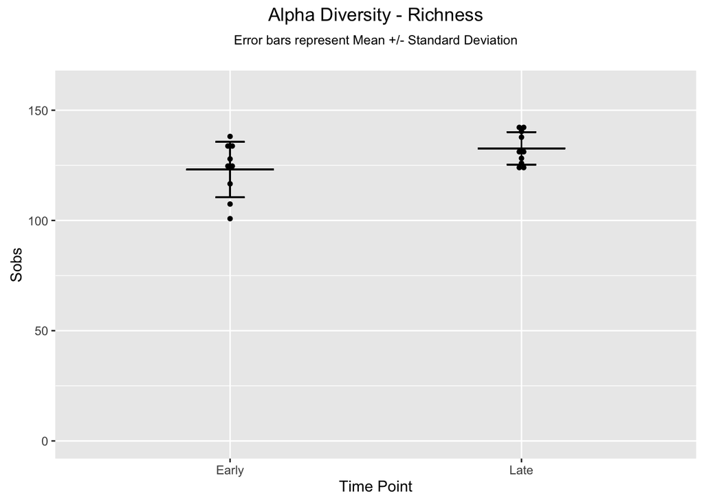

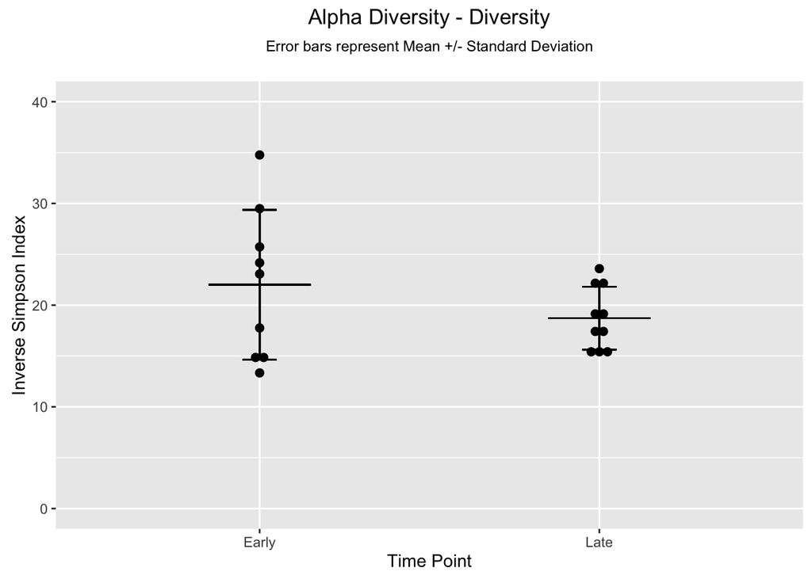

## Beta diversity

Again, with the Release 123 Silva reference files, we see the early and late time points clustering into significantly different groups (AMOVA p <0.001) with the earlier samples having a significantly greater variation (HOMOVA p < 0.001) than the later samples (0.0603828 compared to 0.00774273, respectively).

[interactive chart not shown]

## Population Analysis

### Classifications of top OTUs separating Early and Late populations (via metastats)

#### Release 123 Silva Reference files

```
##       OTU mean.group1.
## 1 Otu0005     0.090000
## 2 Otu0006     0.074549
## 3 Otu0012     0.024713
## 4 Otu0016     0.017254
## 6 Otu0020     0.014467
##                                                                                                                                                                                                                                                Taxonomy
## 1 Bacteria(100);Bacteroidetes(100);Bacteroidia(100);Bacteroidales(100);Bacteroidales_S24-7_group(100);Bacteroidales_S24-7_group_unclassified(100);Bacteroidales_S24-7_group_unclassified(100);Bacteroidales_S24-7_group_unclassified_unclassified(100);
## 2 Bacteria(100);Bacteroidetes(100);Bacteroidia(100);Bacteroidales(100);Bacteroidales_S24-7_group(100);Bacteroidales_S24-7_group_unclassified(100);Bacteroidales_S24-7_group_unclassified(100);Bacteroidales_S24-7_group_unclassified_unclassified(100);
## 3 Bacteria(100);Bacteroidetes(100);Bacteroidia(100);Bacteroidales(100);Bacteroidales_S24-7_group(100);Bacteroidales_S24-7_group_unclassified(100);Bacteroidales_S24-7_group_unclassified(100);Bacteroidales_S24-7_group_unclassified_unclassified(100);
## 4                                                    Bacteria(100);Firmicutes(100);Erysipelotrichia(100);Erysipelotrichales(100);Erysipelotrichaceae(100);Turicibacter(100);Turicibacter_unclassified(100);Turicibacter_unclassified_unclassified(100);
## 6 Bacteria(100);Bacteroidetes(100);Bacteroidia(100);Bacteroidales(100);Bacteroidales_S24-7_group(100);Bacteroidales_S24-7_group_unclassified(100);Bacteroidales_S24-7_group_unclassified(100);Bacteroidales_S24-7_group_unclassified_unclassified(100);
```

#### MiSeq SOP Silva Reference files

```
##       OTU mean.group1.
## 1 Otu0004     0.110865
## 2 Otu0005     0.089053
## 3 Otu0006     0.073514
## 6 Otu0016     0.018327
## 9 Otu0020     0.015416
##                                                                                                                                                                                                                    Taxonomy
## 1 Bacteria(100);Bacteroidetes(100);Bacteroidia(100);Bacteroidales(100);Porphyromonadaceae(100);Porphyromonadaceae_unclassified(100);Porphyromonadaceae_unclassified(100);Porphyromonadaceae_unclassified_unclassified(100);
## 2                                   Bacteria(100);Bacteroidetes(100);Bacteroidia(100);Bacteroidales(100);Porphyromonadaceae(100);Barnesiella(100);Barnesiella_unclassified(100);Barnesiella_unclassified_unclassified(100);
## 3 Bacteria(100);Bacteroidetes(100);Bacteroidia(100);Bacteroidales(100);Porphyromonadaceae(100);Porphyromonadaceae_unclassified(100);Porphyromonadaceae_unclassified(100);Porphyromonadaceae_unclassified_unclassified(100);
## 6                        Bacteria(100);Firmicutes(100);Erysipelotrichia(100);Erysipelotrichales(100);Erysipelotrichaceae(100);Turicibacter(100);Turicibacter_unclassified(100);Turicibacter_unclassified_unclassified(100);
## 9 Bacteria(100);Bacteroidetes(100);Bacteroidia(100);Bacteroidales(100);Porphyromonadaceae(100);Porphyromonadaceae_unclassified(100);Porphyromonadaceae_unclassified(100);Porphyromonadaceae_unclassified_unclassified(100);
```

### Classifications of top OTUs separating Early and Late populations (via lefse)

#### Release 123 Silva Reference files

```
##       OTU LogMaxMean
## 1 Otu0005    4.95424
## 2 Otu0006    4.87244
## 3 Otu0012    4.39293
## 5 Otu0017    4.27537
## 4 Otu0016    4.23689
##                                                                                                                                                                                                                                                Taxonomy
## 1 Bacteria(100);Bacteroidetes(100);Bacteroidia(100);Bacteroidales(100);Bacteroidales_S24-7_group(100);Bacteroidales_S24-7_group_unclassified(100);Bacteroidales_S24-7_group_unclassified(100);Bacteroidales_S24-7_group_unclassified_unclassified(100);
## 2 Bacteria(100);Bacteroidetes(100);Bacteroidia(100);Bacteroidales(100);Bacteroidales_S24-7_group(100);Bacteroidales_S24-7_group_unclassified(100);Bacteroidales_S24-7_group_unclassified(100);Bacteroidales_S24-7_group_unclassified_unclassified(100);
## 3 Bacteria(100);Bacteroidetes(100);Bacteroidia(100);Bacteroidales(100);Bacteroidales_S24-7_group(100);Bacteroidales_S24-7_group_unclassified(100);Bacteroidales_S24-7_group_unclassified(100);Bacteroidales_S24-7_group_unclassified_unclassified(100);
## 5                Bacteria(100);Firmicutes(100);Clostridia(100);Clostridiales(100);Lachnospiraceae(100);Lachnospiraceae_NK4A136_group(100);Lachnospiraceae_NK4A136_group_unclassified(100);Lachnospiraceae_NK4A136_group_unclassified_unclassified(100);
## 4                                                    Bacteria(100);Firmicutes(100);Erysipelotrichia(100);Erysipelotrichales(100);Erysipelotrichaceae(100);Turicibacter(100);Turicibacter_unclassified(100);Turicibacter_unclassified_unclassified(100);
```

#### MiSeq SOP Silva Reference files

```
##       OTU LogMaxMean
## 1 Otu0004    5.04479
## 2 Otu0005    4.94965
## 3 Otu0006    4.86637
## 4 Otu0014    4.29403
## 8 Otu0018    4.27659
##                                                                                                                                                                                                                    Taxonomy
## 1 Bacteria(100);Bacteroidetes(100);Bacteroidia(100);Bacteroidales(100);Porphyromonadaceae(100);Porphyromonadaceae_unclassified(100);Porphyromonadaceae_unclassified(100);Porphyromonadaceae_unclassified_unclassified(100);
## 2                                   Bacteria(100);Bacteroidetes(100);Bacteroidia(100);Bacteroidales(100);Porphyromonadaceae(100);Barnesiella(100);Barnesiella_unclassified(100);Barnesiella_unclassified_unclassified(100);
## 3 Bacteria(100);Bacteroidetes(100);Bacteroidia(100);Bacteroidales(100);Porphyromonadaceae(100);Porphyromonadaceae_unclassified(100);Porphyromonadaceae_unclassified(100);Porphyromonadaceae_unclassified_unclassified(100);
## 4                 Bacteria(100);Firmicutes(100);Clostridia(100);Clostridiales(100);Lachnospiraceae(100);Lachnospiraceae_unclassified(100);Lachnospiraceae_unclassified(100);Lachnospiraceae_unclassified_unclassified(100);
## 8  Bacteria(100);Bacteria_unclassified(100);Bacteria_unclassified(100);Bacteria_unclassified(100);Bacteria_unclassified(100);Bacteria_unclassified(100);Bacteria_unclassified(100);Bacteria_unclassified_unclassified(100);
```

### Classifications of top OTUs with greatest mean decrease between Early and Late populations (via classify.RF)

#### Release 123 Silva Reference files

```
##       OTU Mean.decrease.accuracy Size
## 5 Otu0017                   0.19 1325
## 8 Otu0030                   0.15  643
## 6 Otu0020                   0.14 1196
## 2 Otu0006                   0.13 6648
## 7 Otu0026                   0.13  741
##                                                                                                                                                                                                                                                Taxonomy
## 5                Bacteria(100);Firmicutes(100);Clostridia(100);Clostridiales(100);Lachnospiraceae(100);Lachnospiraceae_NK4A136_group(100);Lachnospiraceae_NK4A136_group_unclassified(100);Lachnospiraceae_NK4A136_group_unclassified_unclassified(100);
## 8                                             Bacteria(100);Firmicutes(100);Clostridia(100);Clostridiales(100);Lachnospiraceae(100);Lachnospiraceae_unclassified(100);Lachnospiraceae_unclassified(100);Lachnospiraceae_unclassified_unclassified(100);
## 6 Bacteria(100);Bacteroidetes(100);Bacteroidia(100);Bacteroidales(100);Bacteroidales_S24-7_group(100);Bacteroidales_S24-7_group_unclassified(100);Bacteroidales_S24-7_group_unclassified(100);Bacteroidales_S24-7_group_unclassified_unclassified(100);
## 2 Bacteria(100);Bacteroidetes(100);Bacteroidia(100);Bacteroidales(100);Bacteroidales_S24-7_group(100);Bacteroidales_S24-7_group_unclassified(100);Bacteroidales_S24-7_group_unclassified(100);Bacteroidales_S24-7_group_unclassified_unclassified(100);
## 7                                                                Bacteria(100);Firmicutes(100);Clostridia(100);Clostridiales(100);Ruminococcaceae(100);Oscillibacter(100);Oscillibacter_unclassified(100);Oscillibacter_unclassified_unclassified(100);
```

#### MiSeq SOP Silva Reference files

```
##        OTU Mean.decrease.accuracy Size
## 11 Otu0030                   0.15  643
## 13 Otu0034                   0.13  541
## 16 Otu0048                   0.11  343
## 7  Otu0017                   0.10 1327
## 6  Otu0016                   0.09 1345
##                                                                                                                                                                                                     Taxonomy
## 11     Bacteria(100);Firmicutes(100);Clostridia(100);Clostridiales(100);Lachnospiraceae(99);Lachnospiraceae_unclassified(99);Lachnospiraceae_unclassified(99);Lachnospiraceae_unclassified_unclassified(99);
## 13 Bacteria(100);Firmicutes(100);Clostridia(100);Clostridiales(100);Lachnospiraceae(100);Lachnospiraceae_unclassified(100);Lachnospiraceae_unclassified(100);Lachnospiraceae_unclassified_unclassified(100);
## 16 Bacteria(100);Firmicutes(100);Clostridia(100);Clostridiales(100);Ruminococcaceae(100);Ruminococcaceae_unclassified(100);Ruminococcaceae_unclassified(100);Ruminococcaceae_unclassified_unclassified(100);
## 7  Bacteria(100);Firmicutes(100);Clostridia(100);Clostridiales(100);Lachnospiraceae(100);Lachnospiraceae_unclassified(100);Lachnospiraceae_unclassified(100);Lachnospiraceae_unclassified_unclassified(100);
## 6         Bacteria(100);Firmicutes(100);Erysipelotrichia(100);Erysipelotrichales(100);Erysipelotrichaceae(100);Turicibacter(100);Turicibacter_unclassified(100);Turicibacter_unclassified_unclassified(100);
```

[^1]: http://www.mothur.org/wiki/Silva_reference_files
[^2]: http://www.mothur.org/wiki/MiSeq_SOP